# Implementing of RankNet

### 3.2 Creating Data cf9ab26

The first step is to create a simple data set and design a neural network that can classify that data set, the data set generated should have two classes of data (this could be interpreted as relevant and irrelevant documents given the features or principle components of a data set), this can be implemented using sci kit learn as shown below and visualized<sup>5</sup> in figure 1.<sup>6</sup>

In order to fit a Neural Network the *PyTorch* package can be used NEURIPS2019_9015, this will allow the gradients of the neural network to be calculated numerically without needing to solve for the partial derivatives, hence the data will need to be in the form of tensors.

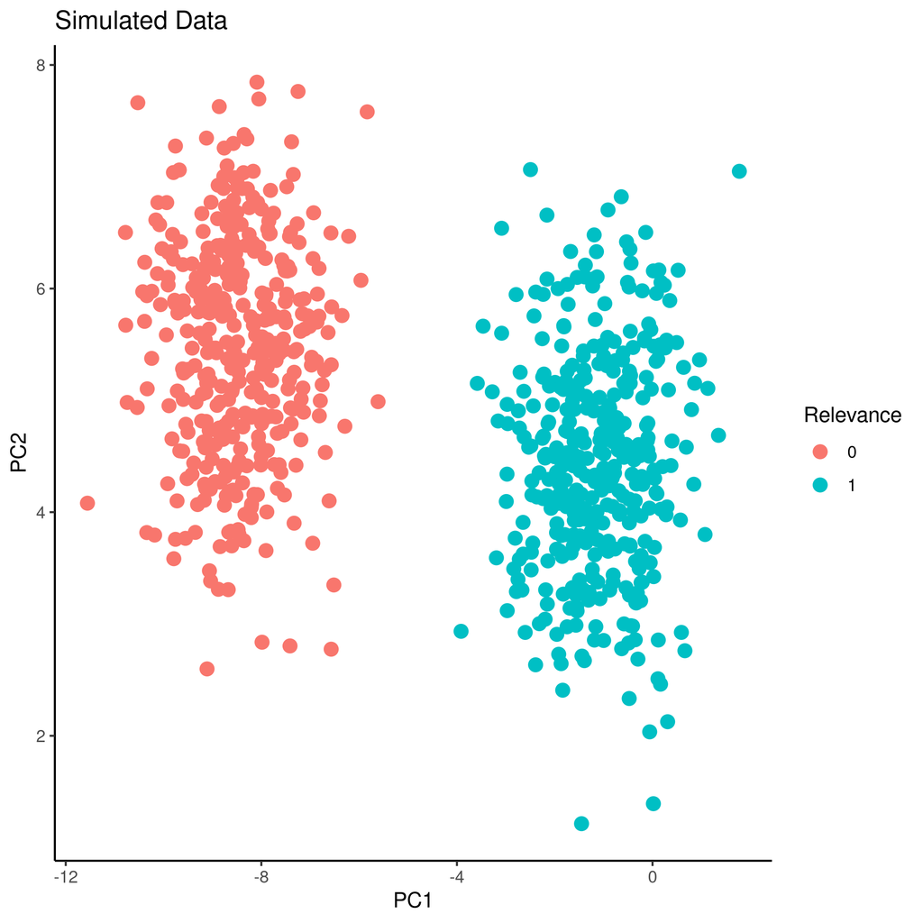

```python
def make_data(create_plot=False, n=1000, dtype=torch.float, dev="cpu", export=""):
    X, y = datasets.make_blobs(n, 2, 2, random_state=7)
    # X, y = datasets.make_moons(n_samples=n, noise=0.1, random_state=0) # Moons Data for later

    # Save the data somewhere if necessary
    if export != "":
        export_data(X, y, export)

    # Reshape the data to be consistent
    y = np.reshape(y, (len(y), 1))  # Make y vertical n x 1 matrix.

    # -- Split data into Training and Test Sets --------------------
    data = train_test_split(X, y, test_size=0.4)

    if(create_plot):
        # Create the Scatter Plot
        plt.scatter(X[:, 0], X[:, 1], c=y)
        plt.title("Sample Data")
        plt.show()

    # Make sure we're working with tensors not mere numpy arrays
    torch_data = [None]*len(data)
    for i in range(len(data)):
        torch_data[i] = torch.tensor(data[i], dtype=dtype, requires_grad=False)

    return torch_data

# Set Torch Parameters
dtype = torch.float
dev = test_cuda()

# Generate the Data
X_train, X_test, y_train, y_test = make_data(
    n=int(300/0.4), create_plot=True, dtype=dtype, dev=dev, export = "/tmp/simData.csv")
```

Figure 1: Generated data, output classes denote document relevance and the axis features or principle components

### 3.3 Creating a Neural Network 7291112

A Neural Network model can be designed as a class, here a 2-layer model using Sigmoid functions has been described, this design was chosen for it's relative simplicity:

```python
class three_layer_classification_network(nn.Module):
    def __init__(self, input_size, hidden_size, output_size, dtype=torch.float, dev="cpu"):
        super(three_layer_ranknet_network, self).__init__()
        self.wi = torch.randn(input_size, hidden_size,
                              dtype=dtype,
                              requires_grad=True,
                              device=dev)
        self.wo = torch.randn(hidden_size, output_size,
                              dtype=dtype,
                              requires_grad=True,
                              device=dev)

        self.bi = torch.randn(hidden_size,
                              dtype=dtype,
                              requires_grad=True,
                              device=dev)
        self.bo = torch.randn(output_size,
                              dtype=dtype,
                              requires_grad=True,
                              device=dev)

        self.σ = torch.randn(1, dtype=dtype, requires_grad=True, device=dev)

        self.losses = []       # List of running loss values
        self.trainedQ = False  # Has the model been trained yet?

    def forward(self, x):
        x = torch.matmul(x, self.wi).add(self.bi)
        x = torch.sigmoid(x)
        x = torch.matmul(x, self.wo).add(self.bo)
        x = torch.sigmoid(x)
        return x

    def loss_fn(self, x, y):
        y_pred = self.forward(x)
        return torch.mean(torch.pow((y-y_pred), 2))

    def misclassification_rate(self, x, y):
        y_pred = (self.forward(x) > 0.5)
        return np.average(y != y_pred)
```

```python
# Set Seeds
torch.manual_seed(1)
np.random.seed(1)

# Set Torch Parameters
dtype = torch.float
dev = test_cuda()

# Make the Data
X_train, X_test, y_train, y_test = make_data(
    n=100, create_plot=True, dtype=dtype, dev=dev)

# Create a model object
model = three_layer_classification_network(
    input_size=X_train.shape[1], hidden_size=2, output_size=1, dtype=dtype, dev=dev)

# Send some data through the model
print("\nThe Network input is:\n---\n")
print(X_train[7,:], "\n")
print("The Network Output is:\n---\n")
print(model.forward(X_train[7,:]).item(), "\n")
```

```
The Network input is:
---

tensor([-1.5129,  2.9332])

The Network Output is:
---

0.22973690927028656
```

### 3.4 Train the Model with Gradient Descent 7d46636

Now that the model has been fit, a method to train the model can be implmented <sup>8</sup>:

```python
class three_layer_classification_network(nn.Module):
    # __init__ method goes here, see above
    # ...
    # ...

    def train(self, x, target, η=30, iterations=2e4):
        bar = Bar('Processing', max=iterations) # progress bar
        for t in range(int(iterations)):

            # Calculate y, forward pass
            y_pred = self.forward(x)

            # Measure the loss
            loss = self.loss_fn(x, target)

            # print(loss.item())
            self.losses.append(loss.item())

            # Calculate the Gradients with Autograd
            loss.backward()

            with torch.no_grad():
                # Update the Weights with Gradient Descent
                self.wi -= η * self.wi.grad; self.wi.grad = None
                self.bi -= η * self.bi.grad; self.bi.grad = None
                self.wo -= η * self.wo.grad; self.wo.grad = None
                self.bo -= η * self.bo.grad; self.bo.grad = None
                self.σ  -= η * self.σ.grad;  self.σ.grad = None
            bar.next()
        bar.finish()
                # ; Zero out the gradients, they've been used

    # Rest of the Class Definition Below ...VVV...
```

```python
# Make the Data
X_train, X_test, y_train, y_test = make_data(
    n=100, create_plot=True, dtype=dtype, dev=dev)

# Create a model object
model = three_layer_classification_network(
    input_size=X_train.shape[1], hidden_size=2, output_size=1, dtype=dtype, dev=dev)

# Train the Model
model.train(X_train, y_train, η=1e-2, iterations=10000)

# Plot the losses
plt.plot(model.losses)
plt.title("Losses at each training iteration")
plt.show()

print("The testing misclassification rate is:\n")
print(model.misclassification_rate(X_test, y_test))
```

[output not shown]

### 3.5 Implement Ranknet f25f376 05df04f

Now that the model can classify the data, the implementation will be modified to:

- Measure loss using a BCE function which is reported to perform better in the literature christopherburgesRankNetRankingRetrospective2015,christopherburgesRankNetLambdaRankLambdaMART2010
- Modify the model so that it operates pairwise, such that:
  1. Two points are identified, sent through the neural network and two values returned:

     \begin{align} s_i = n(\mathbf{X}_i) \label{eq:forward_single1}\\ s_j = n(\mathbf{X}_j) \label{eq:forward_single2} \end{align}

     The network previously created can be adapted for this and hence the method will be renamed to `forward_single` and this will represent function \(n()\) implemented in \eqref{eq:forward_single1} and \eqref{eq:forward_single2}
  2. These values will be combined to give a single value which is intended to measure the model confidence:<sup>9</sup>

     \begin{align} \bar{P}_{ij} & \leftarrow p_i - p_j \\ \bar{P}_{ij} & \leftarrow \frac{1+\bar{P}_{ij}}{2} \end{align}

These modifications only need to be made to the neural network class like so:

```python
class three_layer_ranknet_network(nn.Module):
    # __init__ method
    # ...
    # ...

    def forward(self, xi, xj):
        si = self.forward_single(xi)
        sj = self.forward_single(xj)
        out = 1 / (1 + torch.exp(-self.σ * (si - sj)))
        return out

    def forward_single(self, x):
        x = torch.matmul(x, self.wi).add(self.bi)
        x = torch.sigmoid(x)
        x = torch.matmul(x, self.wo).add(self.bo)
        x = torch.sigmoid(x)

        return x

    def loss_fn(self, xi, xj, y):
        y_pred = self.forward(xi, xj)
        loss = torch.mean(-y * torch.log(y_pred) -
                          (1 - y) * torch.log(1 - y_pred))
        return loss

   def pairwise(iterable):
       "pairwise([1,2,3,4]) --> [(1, 2), (1, 3), (1, 4), (2, 3), (2, 4), (3, 4)]"
       s = list(iterable)
       pair_iter = chain.from_iterable(combinations(s, r) for r in [2])
       return pair_iter
```

The training method must be adapted to interact with these changes like so:<sup>11</sup>

```python
class three_layer_ranknet_network(nn.Module):
    # __init__ method
    # ...
    # ...
    def train(self, x, target, η=1e-2, iterations=4e2):
        self.trainedQ = True
        # Create a progress bar
        bar = Bar('Processing', max=iterations)
        # Train for a number of iterations
        for t in range(int(iterations)):
            sublosses = []
            # Loop over every pair of values
            for pair in pairwise(range(len(x) - 1)):
                xi, yi = x[pair[0], ], target[pair[0]]
                xj, yj = x[pair[1], ], target[pair[1]]

                # encode from {0, 1} to {-1, 0, 1}
                y = yi - yj

                # Scale between {0,1}
                y = 1 / 2 * (1 + y)

                # Calculate y, forward pass
                y_pred = self.forward(xi, xj)

                # Measure the loss
                loss = self.loss_fn(xi, xj, y)
                sublosses.append(loss.item())

                # Calculate the Gradients with Autograd
                loss.backward()

                # Update the Weights with Gradient Descent
                # ; Zero out the gradients, they've been used
                with torch.no_grad():
                    self.wi -= η * self.wi.grad; self.wi.grad = None
                    self.bi -= η * self.bi.grad; self.bi.grad = None
                    self.wo -= η * self.wo.grad; self.wo.grad = None
                    self.bo -= η * self.bo.grad; self.bo.grad = None
                    self.σ  -= η * self.σ.grad ; self.σ.grad  = None

            self.losses.append(np.average(sublosses))
            bar.next()
        bar.finish()
        self.threshold_train(x, target, plot=False)
```

This can then be implemented as before, the loss function is provided at figure 3.

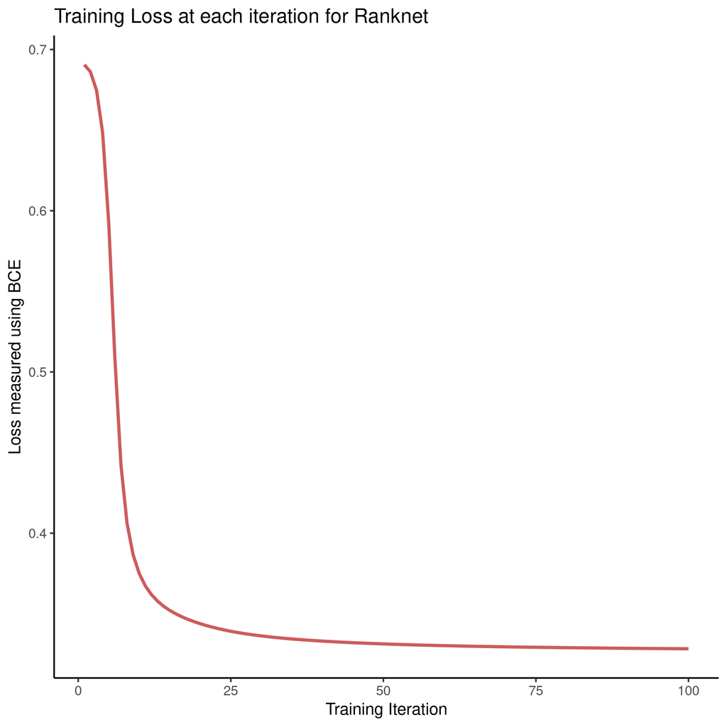

```python
# Make the Data
X_train, X_test, y_train, y_test = make_data(
    n=30, create_plot=True, dtype=dtype, dev=dev)

# Create a model object
model = three_layer_ranknet_network(
    input_size=X_train.shape[1], hidden_size=2, output_size=1, dtype=dtype, dev=dev)

# Train the Model
model.train(X_train, y_train, η=1e-1, iterations=1e2)

# Save the losses
np.savetxt(fname="/tmp/losses.csv", X=model.losses, delimiter=',')
```

Figure 3: BCE training loss at each iteration for the Ranknet method.

One of the difficulties in implementing this, however, is that it is not simple to determine whether or not the model has classified the data well,<sup>12</sup> In order to address this the model can be implemented to sort the data by ranked values and then visualised. To implement this a derivative of the *quicksort* algorithm was chosen as a sorting function hoareAlgorithm64Quicksort1961, this was implemented by adapting code already available in the literature kernighanProgrammingLanguage1988 and online PythonProgramQuickSort2014:

```python
def split(values, left, right, data, model):
    # Define the leftmost value
    l = (left-1)
    # Set the right value as the pivot
    pivot = values[right]  # TODO The pivot should be random

    for q in range(left, right):
        # Only move smaller values left
        if leq(values[q], pivot, data, model):
            # +1 next left element
            l = l+1
            # Swap the current element onto the left
            values[l], values[q] = values[q], values[l]

    # Swap the pivot value into the left position from the right
    values[l+1], values[right] = values[right], values[l+1]
    return (l+1)


def qsort(values, left, right, data, model):
    if len(values) == 1:
        return values
    if right > left:
        # pi is the index of where the pivot was moved to
        # It's position is now correct
        pi = split(values, left, right, data, model)

        # Do this again for the left and right parts
        qsort(values, left, pi-1, data, model)
        qsort(values, pi+1, right, data, model)

import random

def leq(a, b, data, model):
    score = model.forward(data[a, :], data[b, :])
    if score <= 0.5:
        return True
    if score > 0.5:
        return False

        if (a < b):
            return True
        else:
            return False


if DEBUG:
    for i in range(3):
        import random
        values = random.sample(range(9), 7)
        n = len(values)
        print(values)
        qsort(values, 0, n-1, data, model)
        print("==>", values)
```

[figure not shown]

```python
# Main Function
def main():
    # Make the Data
    X_train, X_test, y_train, y_test = make_data(n=100,
                                                 create_plot=True,
                                                 dtype=dtype,
                                                 dev=dev)

    # Create a model object
    model = three_layer_ranknet_network(input_size=X_train.shape[1],
                                        hidden_size=2,
                                        output_size=1,
                                        dtype=dtype,
                                        dev=dev)

    # Train the Model
    model.train(X_train, y_train, η=1e-1, iterations=1e2)

    # Visualise the Training Error
    plot_losses(model)

    # Misclassification won't work for ranked data
    # Instead Visualise the ranking
    plot_ranked_data(X_test, y_test, model)


def plot_losses(model):
    plt.plot(model.losses)
    plt.title("Cost / Loss Function for Iteration of Training")
    plt.show()


def plot_ranked_data(X, y, model):
    # Create a list of values
    n = X.shape[0]
    order = [i for i in range(n)]
    # Arrange that list of values based on the model
    quicksort(values=order, left=0, right=(n - 1), data=X, model=model)
    print(order)

    ordered_data = X[order, :]
    y_ordered = y[order]

    np.savetxt("/tmp/ordered_data.csv", X=ordered_data.numpy(), delimiter=',')

    p = plt.figure()
    for i in range(len(ordered_data)):
        plt.text(ordered_data[i, 0], ordered_data[i, 1], i)
    plt.scatter(ordered_data[:, 0], ordered_data[:, 1], c=y_ordered)
    plt.title("Testing Data, with ranks")
    plt.show()


if __name__ == "__main__":
    main()
```

So instead of ranking, sort the values, this produces the output.

So this is definitely one of the hard issues.

what would be better would be to classify data with a rating (i.e. wine scores), only show the model whether the wine is good/bad and compare the output order with the input order, that would be an effective way to see that it works. This was not yet effectively implemented.

### 3.7 Moons

### 3.8 Optimisers

### 3.9 Batches

### 3.10 Wine

### 3.11 Rank Wiki Articles

## 4 Difficulties

- Don't use torch
  - Do it by hand first because it can be hard to see if the correct weights are being updated sensibly, making debugging very difficult.
  - R or Julia would be easier because counting from 0 get's pretty confusing when dealing with {1, 0}, {-1, 0, 1}.
- Don't use misclassification rate to measure whether the ranking
  - In hindsight this is obvious, but at the time misclassification was a tempting metric because of it's interpretability

  Very difficult to see if the model is working
- A continuous function will still produce an ordered pattern in the ranking of results, even if the model hasn't been trained, so visualising isn't helpful either.
- Implement it on a data set that already has order, obfuscate the order and then contrast the results
  - or use a measurement
- Plot the loss function of the training data live, the model is slow to train and waiting for it to develop was a massive time drain.

## 5 Further Research

### 5.1 Practical Improvements

- Apply this to documents to get a sorted list, like the wine data
- The "Quicksort" algorithm likely needs a random pivot to be efficient timroughgardenQuicksortOverview2017

### 5.2 Evaluate performance improvements

It is still not clear how the performance of Ranknet compares to traditional approaches implemented by search engines (see § 9.1), further study would ideally:

- Write a program to query a corpus of documents using an existing search engine.
  - Or possibly just implement TF-IDF weighting in order to remove variables.
- Extend the program to implement machine learned ranking
- Measure and contrast the performance of the two models to see whether there are any significant improvements.

This could be implemented with TREC datasets usnationalinstituteofstandardsandtechnologyTextREtrievalConference using a cummulated-gain cost function jarvelinCumulatedGainbasedEvaluation2002 as demonstrated in previous work viksinghComparisonOpenSource2009.

### 5.3 Evaluate alternative machine learning models

i.e. can SVM's or trees be used instead of neural networks?

## 6 Conclusion

## 7 Text and References

This is a Reference tuGraphBasedSemiSupervisedNearestNeighbor2016a and another nicodemiIntroductionAbstractAlgebra2007a and yet another christopherburgesRankNetLambdaRankLambdaMART2010.

## 9 Appendix

### 9.1 Search Engines

There are many open source search engines available , a cursory review found the following popular projects:

- [Zettair](https://github.com/cyclaero/zettair) (`C`) jansenCyclaeroZettair2020
- [Apache lucene/Solr](https://github.com/apache/lucene-solr) (`Java`) apachesoftwarefoundationLearningRankApache2017
  - Implemented by [DocFetcher](https://sourceforge.net/p/docfetcher/code/ci/master/tree/) docfetcherdevelopmentteamDocFetcherFastDocument
- [Sphinx](https://github.com/sphinxsearch/sphinx) (`C++`) yurischapovSphinxsearchSphinx2021
- [Xapian](https://github.com/kevinduraj/xapian-search) (`C++`) ollybettsXapianXapian2021
  - Implemented by [Recoll](https://www.lesbonscomptes.com/recoll/) jean-francoisdockesRecollUserManual

More Modern Search engines include:

- [LunrJS](https://github.com/olivernn/lunr.js/) (`JS`) nightingaleOlivernnLunrJs2021
- [Bleve Search](https://github.com/blevesearch/bleve) (`Go`) martyschochBleveSearchDocumentation
- [Riot](https://github.com/go-ego/riot) (`Go`) vzGoegoRiot2021
- [Tantivy](https://github.com/tantivy-search/tantivy) (`Rust`) clementrenaultMeilisearchMeiliSearch2021
- [SimSearch](https://github.com/andylokandy/simsearch-rs) (`Rust`) lokAndylokandySimsearchrs2021

#### 9.1.1 Fuzzy String Match

Somewhat related are programs that rank string similarity, such programs don't tend to perform well on documents however (so for example these would be effective to filter document titles but would not be useful for querying documents):

- [`fzf`](https://github.com/junegunn/fzf) choiJunegunnFzf2021
- [`fzy`](https://github.com/jhawthorn/fzy) hawthornJhawthornFzy2021
- [`peco`](https://github.com/peco/peco) lestrratPecoPeco2021
- [Skim](https://github.com/lotabout/skim) zhangLotaboutSkim2021
- [`go-fuzzyfinder`](https://github.com/lotabout/skim) ktrKtr0731Gofuzzyfinder2021
- [Swiper](https://github.com/lotabout/skim) krehelAboaboSwiper2021

### 9.2 Import Statements

The following import statements were included, where used, <sup>14</sup> separate scripts were used to make the model as modular as possible, such corresponding inputs have also been listed:

```python
# Import Packages
from itertools import chain
from itertools import combinations
from itertools import tee
from progress.bar import Bar
import math as m
import matplotlib.pyplot as plt
import numpy as np
import random
import sys
import sys
import torch
import torch
from torch import nn

# Sepereate Scripts lcated below main
from ranknet.test_cuda import test_cuda
from ranknet.make_data import make_data
from ranknet.neural_network import three_layer_ranknet_network
from ranknet.quicksort import quicksort
```

### 9.3 Export Data Method

The data was exported by printing the values to a text file like so:

```python
def export_data(X, y, export):
    try:
        os.remove(export)
        print("Warning, given file was over-written")
    except:
        pass

    with open(export, "a") as f:
        line = "x1, x2, y \n"
        f.write(line)
        for i in (range(X.shape[0])):
            line = str(X[i][0]) + ", " + str(X[i][1]) + ", " + str(y[i]) + "\n"
            f.write(line)
    print("Data Exported")
```

### 9.4 Version Control Repository

The `git` repository used in production of this code is currently available on *GitHub* at github.com/CRMDS/CRMDS-HDR-Training-2020, in order to get a local copy, execute the following commands (`bash`):

```bash
# Clone the repository
git clone https://github.com/CRMDS/CRMDS-HDR-Training-2020

# Change to the subdirectory
cd CRMDS-HDR-Training-2020/ranknet

# Checkout the Walkthrough branch
git checkout walkkthrough

# list the changes
git log
```

Consider the use of tools like [magit](https://magit.vc/) MagitMagit2008 and git-timemachine peterstiernstromEmacsmirrorGittimemachine2014 (or [GitLens](https://marketplace.visualstudio.com/items?itemName=eamodio.gitlens) amodioEamodioVscodegitlens2016 and [git-temporal](https://marketplace.visualstudio.com/items?itemName=bee.git-temporal-vscode) beewilkersonGittemporalGittemporalMono2018 in VsCode) in order to effectively preview the changes at each step, alternatively a pager like bat peterSharkdpBat2018 can also be used with something like fzf choiJunegunnFzf2021 like so:

```bash
git log | grep '^commit' | sed 's/^commit\ //' |\
    fzf --preview 'git diff {}^! |\
     bat --color always'
```

#### 9.4.1 Version Control Log for Walkthrough

| *Commit ID* | *Message* |
| --- | --- |
| `ed5f4cf` | *Initial Commit* |
| `075acf9` | *Walkthrough Initial Commit* |
| `cf9ab26` | *Generate data to use for classification* |
| `7291112` | *Create a Neural Network Model* |
| `7d46636` | *Implement gradient descent to train neural network* |
| `f25f376` | *Adapt Neural Network to perform Ranking* |
| `42509ab` | *Implement sorting algorithm to visualise ranking order* |
| `05df04f` | *Adapt Neural Network to perform Ranking* |
| `99b390a` | *Implement sorting algorithm to visualise ranking order* |
| `473dce3` | *Implement optimizer to replace mere gradient descent* |
| `4141e92` | *Train Model using Batches not entire dataset* |
| `a2671a6` | *Format code to make it more readable* |
| `d11e607` | *plot and only train on different ranked pairs* |

## Footnotes:

<sup>1</sup>

An early goal of this research was to evaluate the performance of different machine learning algorithms to implement the Ranknet method, as well as contrasting this with simple classification approaches, this research however is still ongoing, see § 5.3

<sup>2</sup>

**RMSE** *Root Mean Square Error*

<sup>3</sup>

**BCE** *Binary Cross Entropy*

<sup>4</sup>

crmds.github.io/CRMDS-HDR-Training-2020/

<sup>5</sup>

See § 9.3 for the specific method definition used to export the data to a `csv.`

<sup>6</sup>

Visualisations for this Report were implemented using `org-babel` dominikOrgModeReference2018 inside *Emacs* stallmanGNUEmacsManual2002 to call *R* rcoreteamLanguageEnvironmentStatistical2021 with *GGPlot2* wickhamGgplot2ElegantGraphics2016a (and *Tidyverse* wickhamWelcomeTidyverse2019 generally), the source code for this is avaliable in the report manuscript available in the `git` repository available at github.com/RyanGreenup/ranknet/blob/main/Report/Report.org

<sup>7</sup>

note that the model has not yet been trained, the weights are random and the model output is not related to the data at all.

<sup>8</sup>

This class definition is incomplete and serves only to show the method definition corresponding to the original class shown in § 3.3

<sup>9</sup>

This value is a measurement of the models "confidence" but could be extended to represent the "measured probability" of one item being ranked higher than an other (e.g. the probability that a person would rank one type of wine as better than the other in a random sample).

<sup>10</sup>

Note the convention that the symbols \(\triangleleft, \enspace \triangleright\) have been adopted to denote the ranking of two observations, analogous to \(<, \enspace >\)

<sup>11</sup>

Note the definition of the `pairwise` function, this was incorrectly implemented initially (`f25f376`) and rectified shortly after (`05df04f`). see 9.4.1

<sup>12</sup>

A naive misclassification method was implemented (`f25f376`), but it was not very insightful and so was omitted from this report.

<sup>13</sup>

In this case the plot has been generated by *GGPlot2* <sup>6</sup>

<sup>14</sup>

Including `import` statements where they are not used is fine, other than complaints from a *linter* following *PEP* nickcoghlanPEPStyleGuide2001 (e.g. [autopep](https://pypi.org/project/autopep8/) hattoriAutopep8ToolThat) the code will function just fine.

Author: Ryan Greenup

Created: 2021-02-21 Sun 14:32

[Validate](https://validator.w3.org/check?uri=referer)